# Análisis de la contaminación en estaciones de monitoreo del aire seleccionadas de Lima Metropolitana, un estudio de 2015 a 2018

### Probabilidad Condicional - Eventos Dependientes

#### Elección de variables

- Debido a que los contaminantes PM2.5 están contenidos dentro de los contaminantes PM10, es muy probable que exista dependencia entre estos eventos.
- Además de análisis descriptivo, podemos ver que existe una correlación muy fuerte entre estas dos variables.

#### Comprobacion

- Si A y B son independientes, por probabilidad condicional, se debería cumplir
  $$P(A\cap B) = P(A)P(B) \\
  P(A|B) = \frac{P(A\cap B)}{P(B)} = P(A)$$
- Entonces primero calculamos P(A), P(B) y P(A)P(B), que respectivamente sería:

```
## [1] 0.8520873
```

```
## [1] 0.6307336
```

```
## [1] 0.53744
```

- Segundo calculamos $P(A\cap B)$ empíricamente:

```r
Panb <- a11/BD_size
Panb
```

```
## [1] 0.5911928
```

- Tercero calculamos $P(A|B)$ empíricamente:

```r
Pa_b = a11/Tb
Pa_b
```

```
## [1] 0.9373099
```

- Y por último Bayes. Tomando en cuenta que ya se cálculo $P(A\cap B)$ (ojo: Se usó $\frac{P(A\cap B)}{P(B)}$ para su cálculo empírico). Entonces, procedemos a hallar:
  $$P(B|A) = \frac{P(A|B)P(B)}{P(A)} =
  \frac{P(A|B)P(B)}{P(A|B)P(B)+P(A|B^c)P(B^c)}$$
- Para ello primero hallamos $P(A|B^c)$

```
## [1] 0.7065209
```

```r
Pa <- Pa_b*Pb + Pa_bc*(1-Pb)
Pa
```

```
## [1] 0.8520873
```

- Y P(B|A) seria:

```r
Pa_b*Pb/Pa
```

```
## [1] 0.6938172
```

- Recordemos que P(B) es:

```r
Pb
```

```
## [1] 0.6307336
```

### Variables Discretas

- Para ambos casos de examinación, crearemos unas variables categóricas extras para poder analizar mas a profundidad los contaminantes que consideramos mas peligrosos, como se mencionó en probabilidad empírica, estas serian PM2.5 y O3

##### Propiedades Generales:

- Se buscará verificar que se cumplen las siguientes propiedades generales para calcular la esperanza y varianza en variables aleatorias discretas:
  $$E[X] = \sum_{i=0}^n x_i*P(X=x_i)
  \\ V[X] = E[(X-E[X])^2] = E[X^2]-E[X]^2$$

```r
esperanza = function(x,p){
  return(sum(x*p))
}
varianza = function(x,p){
  return(esperanza(x^2,p)-(esperanza(x,p)^2))
}
```

#### Distribución Binomial

- Crearemos una variable extra en nuestra base de datos, que intentará clasificar las cantidades de PM2.5, el cual consideramos el contaminante mas dañino, en 3 diferentes grupos, nivel bajo, que abarcara de 0 a 10 $\mu g/m^3$, nivel medio de 10 a 50 $\mu g/m^3$, y alto para cantidades mayores a 50$\mu g/m^3$.

```
## # A tibble: 34,926 x 2
##    PM2.5 nivelPM2.5
##    <dbl> <chr>
##  1  20.9 Medio
##  2  24.6 Medio
##  3  42.5 Medio
##  4  52.9 Alto
##  5  72.8 Alto
##  6  86.2 Alto
##  7  91.6 Alto
##  8  94.7 Alto
##  9  97.8 Alto
## 10  81.5 Alto
## # i 34,916 more rows
```

##### Variable Aleatoria

- Ahora definiremos como éxito cuando se detecta un nivelPM2.5 bajo, por lo que:
- **X:# de veces que se registra un nivel de PM2.5 bajo en las 34926 observaciones**

##### Parámetros

- Dado **X~Bin(n,p)**; donde p es probabilidad éxito, y n es tamaño de la muestra, calculamos p para nuestra caso

```
## [1] 0.1479127
```

- Entonces tendremos **X~Bin(34926, 0.1479127)**

##### Gráfica de función de probabilidad

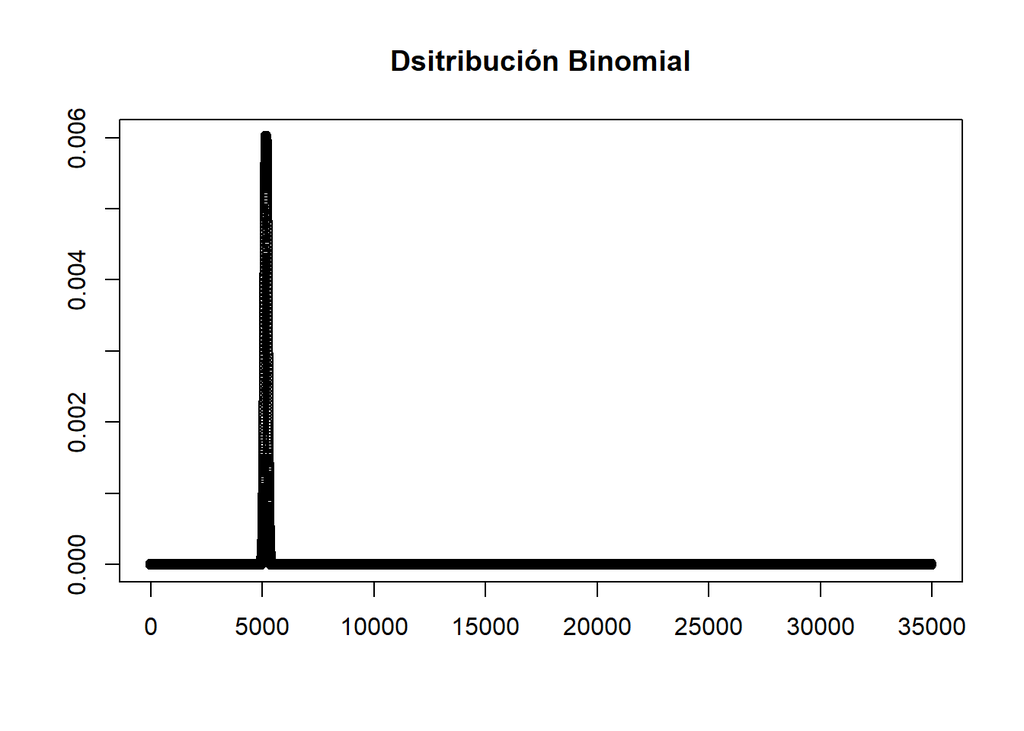

- Haciendo un acercamiento, podemos ver la forma esperada para una distribución binomial

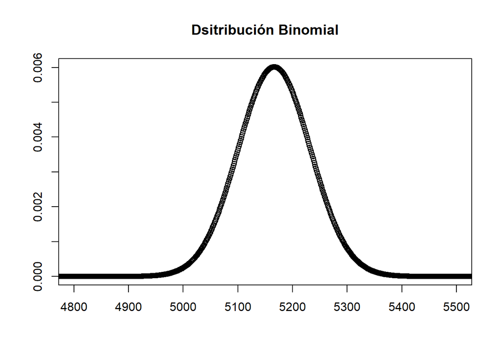

##### Propiedades Distribucion Binomial:

- Se buscará verificar que se cumple:
  $$E[X] = np \\ Var[X] = np(1-p)$$
  Primero hallaremos $E[X] = \sum_{i=0}^n x_i*P(X=x_i)$

```r
esperanza(x,probability_function)
```

```
## [1] 5166
```

- Por otro lado, n*p:

```r
BD_size*Pexito
```

```
## [1] 5166
```

- Ahora hallaremos
  $$V[X] =
  E[X^2]-E[X]^2$$

```r
varianza(x, probability_function)
```

```
## [1] 4401.883
```

- Y según distribución binomial:

```r
BD_size*Pexito*(1-Pexito)
```

```
## [1] 4401.883
```

##### Ejemplo

```r
pbinom(22.5, size = 150, prob = Pexito)
```

```
## [1] 0.5394028
```

##### Resultado

- **Podemos confirmar que la variable aleatoria propuesta cumplen con las propiedades de distribución binomial y por lo tanto sigue tal distribución**

#### Distribución Geométrica

- Crearemos una variable extra en nuestra base de datos, que intentará clasificar las cantidades de O3, el cual consideramos el segundo contaminante mas dañino, en 3 diferentes grupos, nivel bajo, que abarcara de 0 a 30 $\mu g/m^3$, nivel medio de 30 a 50$\mu g/m^3$, y alto para cantidades mayores a 50$\mu g/m^3$.

[output not shown]

##### Variable Aleatoria

- Ahora definiremos como éxito el seleccionar un registro con nivelO3 medio, por lo que:
- **X:# de veces que se selecciona un registro hasta seleccionar un registro con nivelO3 medio**

##### Parámetros

- Dado **X~Geometrica(p)**; donde p es probabilidad éxito

```
## [1] 0.1310199
```

- Entonces tendremos **X~Geometrica(0.1310199)**

##### Gráfica de función de probabilidad

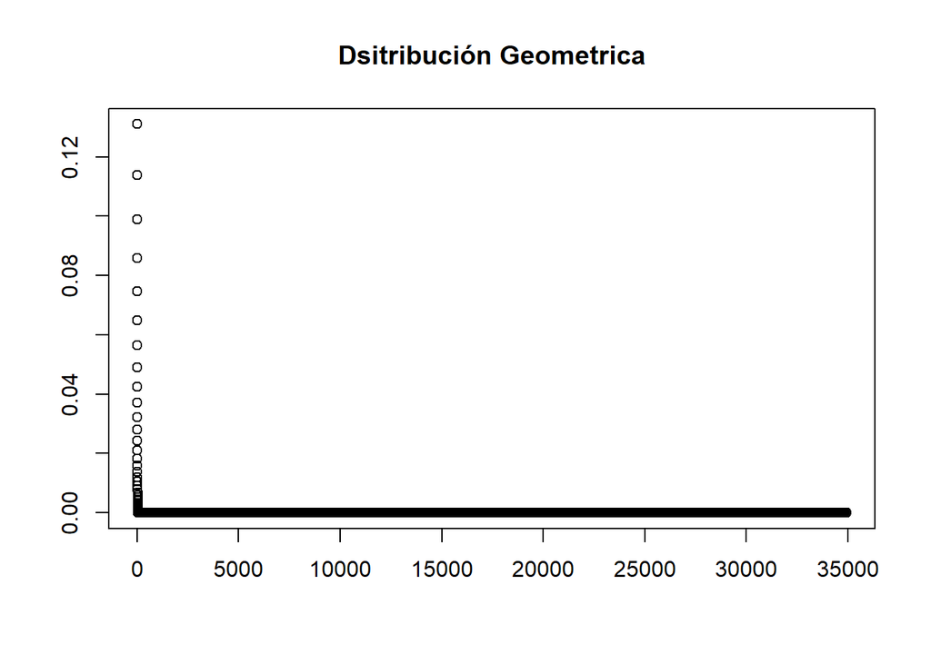

- Haciendo un acercamiento, podemos ver la forma esperada para una distribución geométrica

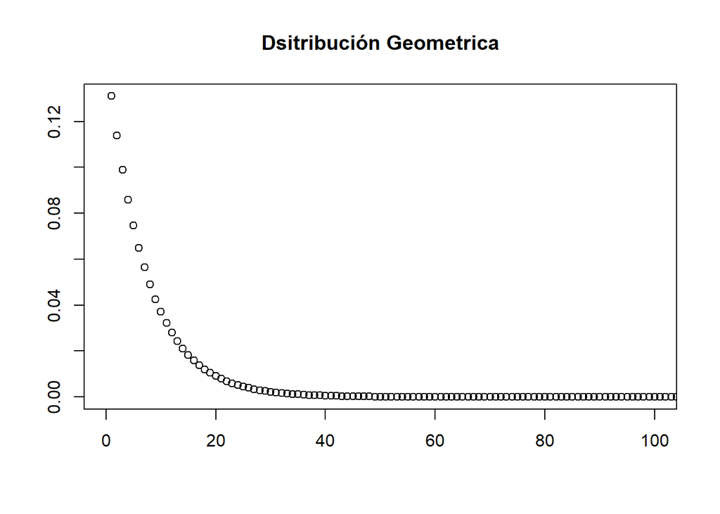

- Se buscará verificar que se cumple:
  $$E[X] = \frac{1-p}{p} \\
  Var[X]=\frac{1-p}{p^2}$$
  Primero hallaremos $E[X] = \sum_{i=0}^n x_i*P(X=x_i)$

```r
esperanza(x,probability_function)
```

```
## [1] 6.63243
```

- Por otro lado, $\frac{1-p}{p}$:

```r
(1-Pexito)/Pexito
```

```
## [1] 6.63243
```

- Ahora hallaremos
  $$V[X] =
  E[X^2]-E[X]^2$$

```r
varianza(x, probability_function)
```

```
## [1] 50.62156
```

```r
(1-Pexito)/Pexito^2
```

```
## [1] 50.62156
```

##### Ejemplo

- Luego de cierto día se llega a registrar cierta cantidad de lecturas de contaminante O3. Se quiere saber la probabilidad de tener que leer a lo mucho 20 registros hasta encontrar una cantidad con nivel de O3 medio.
- Solución:
  - Se puede decir que piden hallar $P(X\leq 20)$, si sabemos que X ~ Geometrico(p)
  - Por lo que la probabilidad de tener que leer a lo mucho 20 registros para encontrar una cantidad con nivel de O3 medio es $\approx 0.947615$

```r
pgeom(20, prob = Pexito)
```

```
## [1] 0.947615
```

##### Resultado

- **Podemos confirmar que la variable aleatoria propuesta cumplen con las propiedades de distribución geómetrica y por lo tanto sigue tal distribución**

### Variables Continuas

#### **PM10 Y PM2.5**

Analizando la infomación del Estándar de Calidad del Aire (ECA) la cual es un instrumento de gestión ambiental establecido para poder medir la calidad del aire, definimos gracias a estos estándares escogemos las variables PM10 y PM2.5 que están limitadas a un valor máximo de 100$ug/m^3$ y 50$ug/m^3$, respectivamente.

Para su respectivo analzis calculamos la Distribución para ambas variables(Mediana,Media,DS,Varianza).

#### Distribución:

- Mediana PM10 $ug/m^3$

```r
median(BDC$PM10)
```

```
## [1] 62.75
```

- Media PM10 $ug/m^3$

```r
mean(BDC$PM10)
```

```
## [1] 75.7649
```

- Desviación estándar^2 PM10 $ug/m^3$

```r
sd(BDC$PM10)^2
```

```
## [1] 2454.557
```

- Varianza PM10 $ug/m^3$

```r
var(BDC$PM10)
```

```
## [1] 2454.557
```

#### Para PM2.5:

- Mediana PM2.5 $ug/m^3$

```r
median(BDC$PM2.5)
```

```
## [1] 19.3
```

- Media PM2.5 $ug/m^3$

```r
mean(BDC$PM2.5)
```

```
## [1] 25.28865
```

- Desviación estándar^2 PM2.5 $ug/m^3$

```r
sd(BDC$PM2.5)^2
```

```
## [1] 383.0281
```

- Varianza PM2.5 $ug/m^3$

```r
var(BDC$PM2.5)
```

```
## [1] 383.0281
```

Las variables de PM10 Y PM2.5 se asume o se aproxima como una distribución normal debido que no hay una completa simetría entre la media y la mediana, esto se debe por los datos atípicos que son usados en el análisis de la contaminación debido que estos valores captados por los sensores en cada estación.

Para determinar la probabilidad de que cada contaminante sobrepase la del limite establecido por el ECA se procede a realizar una gráfica de densidad para cada variable.

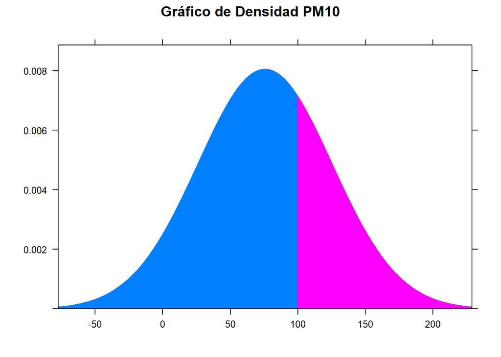

- Se calcula la probabilidad de que la cantidad de contaminantes de PM10 sobrepase el limite permitido según el ECA

```r
(1-pnorm((100),mean(BDC$PM10),sd=sd(BDC$PM10)))
```

```
## [1] 0.3123613
```

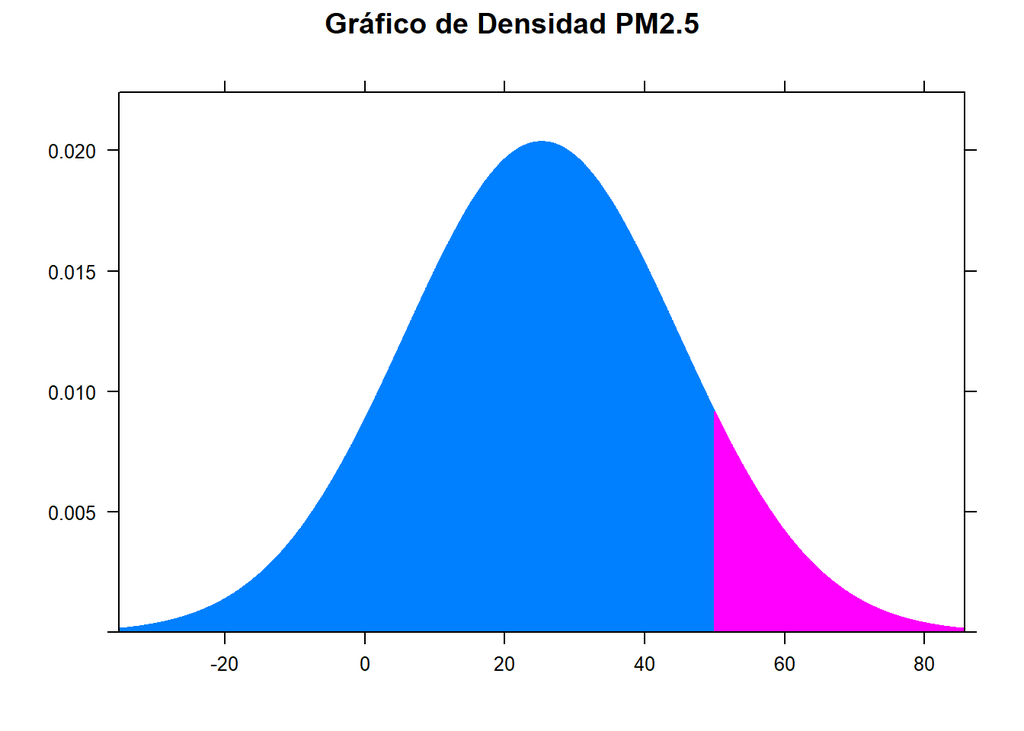

```r
mediap2<-mean(BDC$PM2.5)
smedia2<-sd(BDC$PM2.5)

plotDist("norm", mean =mediap2, sd = smedia2, groups = x >= 50,
  type = "h", main="Gráfico de Densidad PM2.5")
```

- Se calcula la probabilidad de que la cantidad de contaminantes de PM2.5$ug/m^3$ sobrepase el limite permitido según el ECA

```r
(1-pnorm((50),mean(BDC$PM2.5),sd=sd(BDC$PM2.5)))
```

```
## [1] 0.1033585
```

Como se puede observar la probabilidad de que los contaminantes de PM10$ug/m^3$ Y PM2.5$ug/m^3$ superen los establecidos es considerable,siendo 0.31 y 0.1 respectivamente, asimismo el contaminante PM10 es mas probable que supere la cantidad de 100$ug/m^3$.